# mvp_extensions.Rmd

Tamar Yastrab & Hasanat Jahan

6/23/2020

We extended the findings in Predicting the Present with Google Trends http://people.ischool.berkeley.edu/~hal/Papers/2011/ptp.pdf

# Question

Question: Can we use a better model- with either Census Data or additional public datasets- that would beat the trends model? One weakness of the paper is Choi and Varian use an overly simplified model for the baseline data to demonstrate the strength of the trends data that is too easy to beat. We built a better model using only baseline data to demonstrate that even if the trends data is helpful, it is at best as good as the baseline models.

We consider Census Bureau data for other automotive sales and gas stations.

## R Markdown

```r
library(tidyverse)
library(scales)
library(modelr)
library(lubridate)
library(dplyr)
```

We take the real baseline (auto sales) and combine additional CB data. For each feature, we set up for rolling window forecasting and create columns of values from the previous month and current month of the previous year.

```r
base_mvp <- read.csv("real_base_autos.csv") %>%
  rename("Sales" = Value) %>%
  mutate(ymd2 = paste(Period, "-01", sep="")) %>%
  mutate(ymd = as.Date(ymd2, "%b-%y-%d")) %>% select(ymd, Sales)

autos <- read.csv("autos.csv") %>%
  rename("Autos" = Value) %>%
  mutate(ymd2 = paste(Period, "-01", sep="")) %>%
  mutate(ymd = as.Date(ymd2, "%b-%Y-%d")) %>% select(ymd, Autos)

gas <- read.csv("gas_stations.csv") %>%
  rename("Gas" = Value) %>%
  mutate(ymd2 = paste(Period, "-01", sep="")) %>%
  mutate(ymd = as.Date(ymd2, "%b-%Y-%d")) %>% select(ymd, Gas)

mvp <- left_join(autos, base_mvp, by = "ymd") %>% left_join(gas, base_mvp, by = "ymd") %>% mutate(last_month_sales = lag(Sales), last_year_sales = lag(Sales, 12), last_month_autos = lag(Autos), last_month_gas = lag(Gas), last_year_autos = lag(Autos, 12), last_year_gas = lag(Gas, 12)) %>% mutate(row_num = row_number()) %>% mutate(log_sales = log(Sales)) %>% filter(ymd <= "2011-07-01")
```

We set up two models. The first is the standard baseline without additional features and second is the baseline with the additional CB data.

```r
base_model <- lm(Sales ~ last_month_sales + last_year_sales,  data=mvp)
summary(base_model)
```

```
##
## Call:
## lm(formula = Sales ~ last_month_sales + last_year_sales, data = mvp)
##
## Residuals:
##      Min       1Q   Median       3Q      Max
## -11975.6  -2915.2    318.5   2807.9  13346.9
##
## Coefficients:
##                   Estimate Std. Error t value Pr(>|t|)
## (Intercept)      3.513e+03  4.692e+03   0.749    0.456
## last_month_sales 6.209e-01  7.349e-02   8.449 1.52e-12 ***
## last_year_sales  3.223e-01  7.298e-02   4.416 3.28e-05 ***
## ---
## Signif. codes:  0 '***' 0.001 '**' 0.01 '*' 0.05 '.' 0.1 ' ' 1
##
## Residual standard error: 5301 on 76 degrees of freedom
##   (12 observations deleted due to missingness)
## Multiple R-squared:  0.7223, Adjusted R-squared:  0.715
## F-statistic: 98.85 on 2 and 76 DF,  p-value: < 2.2e-16
```

```r
fancy_model <- lm(Sales ~ last_month_sales + last_year_sales + last_month_autos + last_month_gas + last_year_autos + last_year_gas,  data=mvp)
summary(fancy_model)
```

```
##
## Call:
## lm(formula = Sales ~ last_month_sales + last_year_sales + last_month_autos +
##     last_month_gas + last_year_autos + last_year_gas, data = mvp)
##
## Residuals:
##      Min       1Q   Median       3Q      Max
## -10590.1  -2701.7    265.3   3195.0   9756.9
##
## Coefficients:
##                   Estimate Std. Error t value Pr(>|t|)
## (Intercept)      -223.8912  9549.0763  -0.023  0.98136
## last_month_sales   -4.6499     1.9012  -2.446  0.01690 *
## last_year_sales     9.0873     1.6955   5.360 9.58e-07 ***
## last_month_autos    5.4112     1.9449   2.782  0.00689 **
## last_month_gas     -0.1495     0.1204  -1.242  0.21820
## last_year_autos    -8.8772     1.7140  -5.179 1.95e-06 ***
## last_year_gas      -0.3691     0.1405  -2.628  0.01050 *
## ---
## Signif. codes:  0 '***' 0.001 '**' 0.01 '*' 0.05 '.' 0.1 ' ' 1
##
## Residual standard error: 4313 on 72 degrees of freedom
##   (12 observations deleted due to missingness)
## Multiple R-squared:  0.8259, Adjusted R-squared:  0.8114
## F-statistic: 56.91 on 6 and 72 DF,  p-value: < 2.2e-16
```

Test the rpedictions made by this model.

```r
base_prediction = c()
fancy_prediction = c()
mae_base_prediction = c()
mae_fancy_prediction = c()

K <- 17: nrow(mvp) # dates

for (k in K) {
  test_data<- mvp %>% filter(row_num <= k) # only uses previous data
  model_base <- lm(log_sales ~ last_month_sales + last_year_sales , data=test_data)
  model_fancy <- lm(log_sales ~ last_month_sales + last_year_sales + last_month_autos + last_year_autos + last_year_gas + last_month_gas, data=test_data)

  base_prediction[k] <- predict(model_base, test_data)[k]
  fancy_prediction[k] <- predict(model_fancy, test_data)[k]

  mae_base_prediction[k] <- mean(abs(predict(model_base, test_data)[k] - test_data$log_sales))
  mae_fancy_prediction[k] <- mean(abs(predict(model_fancy, test_data)[k] - test_data$log_sales))

}
```

Analyze the error of the result

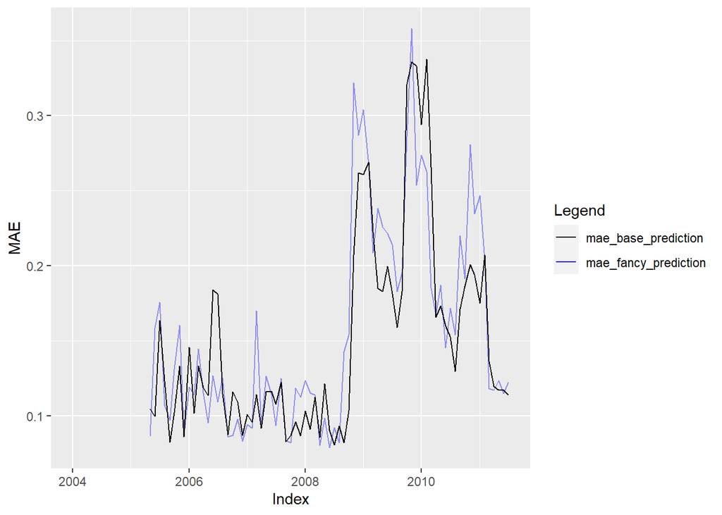

```r
mae_data <- data.frame(mae_base_prediction, mae_fancy_prediction) %>%
  na.omit(mae_base_prediction) %>% mutate(row_num = row_number() + 16)

mae_total <- mvp %>% left_join(mae_data, by = "row_num")

colors <- c("mae_fancy_prediction" = "blue", "mae_base_prediction" = "black")

ggplot(mae_total, aes(x = ymd, y = mae_base_prediction)) +
  geom_line() +
  geom_line(aes(y = mae_fancy_prediction, color = "mae_fancy_prediction"), alpha= 0.4) +
  geom_line(aes(y = mae_base_prediction, color="mae_base_prediction")) +
  labs(x= 'Index', y ='MAE',color = "Legend") +
  scale_color_manual(values=colors) +
  scale_y_continuous()
```

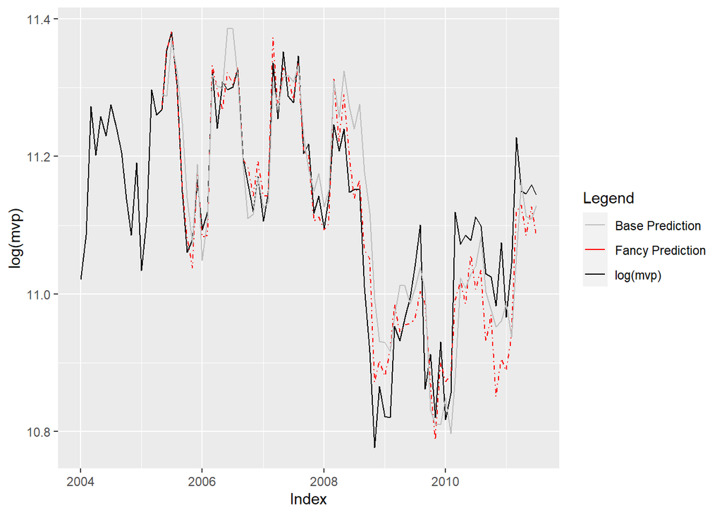

```r
prediction_data <- data.frame(base_prediction, fancy_prediction) %>% na.omit(base_prediction) %>% mutate(row_num = row_number() + 16)
total <- mvp %>% left_join(prediction_data, by = "row_num")

pred_colors = c("Fancy Prediction" = "red", "Base Prediction" = "grey", "log(mvp)"= "black")
ggplot(total, aes(x = ymd, y = log_sales)) +
  geom_line(aes(color = "log(mvp)")) +
  geom_line(aes(y = fancy_prediction, color = "Fancy Prediction"), linetype = "dotdash") +
  geom_line(aes(y = base_prediction, color="Base Prediction")) +
  labs(x='Index',
       y='log(mvp)',
       color="Legend") +
  scale_color_manual(values = pred_colors) +
  scale_y_continuous()
```

# Takeaway